# Wrangle and viz occupation by country of origin

Duc-Quang Nguyen | swissinfo.ch

2017

** Had to install ggiraph 0.3.3 to have responsive charts!?!?!? or latest github version **

** responsive feature for highcharter with github version 0.5.0.9999**

`require(devtools) install_version("ggiraph", version = "0.3.3", repos = "http://cran.us.r-project.org")`

[github issue filed](https://github.com/davidgohel/ggiraph/issues/66)

## Open question

- Use also this xls data to show the change over time?? **ofs xls**

### Dans quelles professions trouve-t-on le plus d’immigrés?

## Data

Voici le fichier les infos reposent sur les données du relevé structurel 2010-2014 combinées. Les effectifs ont été pondérés et extrapolés de manière à correspondre à l’ensemble de la population âgée de 15 ans et plus. Les codes inférieurs à 0 représentent essentiellement des personnes non actives, mais aussi certaines personnes pour lesquelles il n’a pas été possible de déterminer la profession. Le N (dernière colonne) représente le nombre de personnes qui à l’enquête ont déclaré exercer la profession en question. J’ai vidé les cases pour lesquels les calculs reposent sur moins de 10 cas (N< 10).

**[Original NCCR post](http://nccr-onthemove.ch/knowledge-transfer/migration-mobility-indicators/dans-quels-secteurs-economiques-trouve-t-on-le-plus-de-migrant⋅e⋅s/)**

## Related

- [SECO - Comprendre l’immigration des travailleurs qualifiés en Suisse](http://dievolkswirtschaft.ch/fr/2015/11/indergand-12-2015-franz/)
- [Seuls 20% des travailleurs étrangers répondraient au besoin de l’économie](https://www.rts.ch/info/suisse/8203195-seuls-20-des-travailleurs-etrangers-repondraient-au-besoin-de-l-economie.html)
- [TDG - Comment la libre circulation a transformé l’économie suisse](http://www.tdg.ch/suisse/politique/Comment-la-libre-circulation-a-transforme-l-economie-suisse/story/31145377)
- [Avenir Suisse - La Suisse attire](https://www.avenir-suisse.ch/fr/la-suisse-attire-2/)
- [Bilan - La Suisse au top mondial pour les migrations de chercheurs](http://www.bilan.ch/economie-plus-de-redaction/suisse-top-mondial-migrations-de-chercheurs)

### SWI related

- [Etats tiers: Genève, Zurich et Bâle pour une hausse des contingents](https://www.swissinfo.ch/fre/etats-tiers--genève--zurich-et-bâle-pour-une-hausse-des-contingents/43477904)
- [Frein à l’immigration: une solution eurocompatible est en vue](https://www.swissinfo.ch/fre/au-parlement-suisse_frein-à-l-immigration--une-solution-eurocompatible-est-en-vue/42732046)
- [Les plus favorables aux initiatives anti-étrangers sont toujours les mêmes](https://www.swissinfo.ch/fre/le-vote-des-cantons-sous-la-loupe_les-plus-favorables-aux-initiatives-anti-étrangers-sont-toujours-les-mêmes/41990242)

```r
colors <- c( "#193442", "#4c6570", "#7e827a", "#beb298", "#e3cda1", "#aa8959", "#d18768", "#b15953", "#72302f" )

#labelsLieuNaissance<- c("Suisse", "Allemagne")

# add the total by country and aggregate by isco group
adat <- data %>%
  filter(isco >= 1000) %>%
  mutate(group = factor(isco %/% 1000)) %>%
  group_by(group, lieuNaissance) %>%
  summarise(valeur = sum(valeur, na.rm = T)) %>%
  ungroup()

adat <- left_join(adat, byCountryTot) %>%
  mutate(share = (valeur / countryTot) * 100)
byGroupTot <- adat %>% group_by(group) %>%
  summarise(groupTot = sum(valeur, na.rm = T)) %>%
  ungroup() %>%
  mutate(shareTot = (groupTot / sum(groupTot)) * 100)

adat <- left_join(adat, byGroupTot %>% select(group, shareTot)) %>%
  mutate(dev = share - shareTot)
```

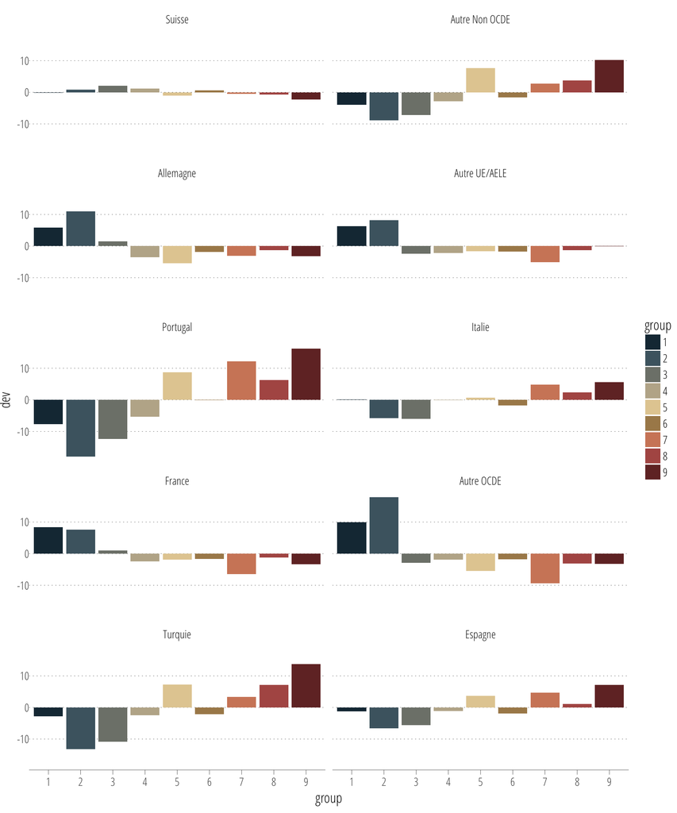

```r
# check
stopifnot(adat %>% group_by(lieuNaissance) %>% summarise(check = sum(dev)) %>%
  ungroup %>% select(check) %>% unlist(use.names = F)  < 10e-2)

ggplot(data = adat) + geom_col(aes(x = group, y = dev, fill = group)) +
  facet_wrap(~ reorder(lieuNaissance, -countryTot), nrow = 5) +
  swi_theme() + scale_fill_manual(values = colors)
```

```r
## Compute deviation for detailed isco codes
dataa <- left_join(
  data %>% filter(isco >= 1000) %>% mutate(group = factor(isco %/% 1000)),
  adat %>% select(group, lieuNaissance, countryTot, dev)
) %>% mutate(shareIsco = (valeur / countryTot) * 100)
byIscoTot <- dataa %>% group_by(isco) %>%
  summarise(iscoTot = sum(valeur, na.rm = T)) %>%
  ungroup() %>%
  mutate(shareTot = (iscoTot / sum(iscoTot)) * 100)

dataa <- left_join(dataa, byIscoTot) %>%
  mutate(devIsco = shareIsco - shareTot)
# check
dataa %>% group_by(lieuNaissance) %>% summarise(test = sum(shareTot), test2 = sum(shareIsco, na.rm = T)) %>%
  ungroup() %>% mutate(check = )
```

# A tibble: 10 x 3

[output not shown]

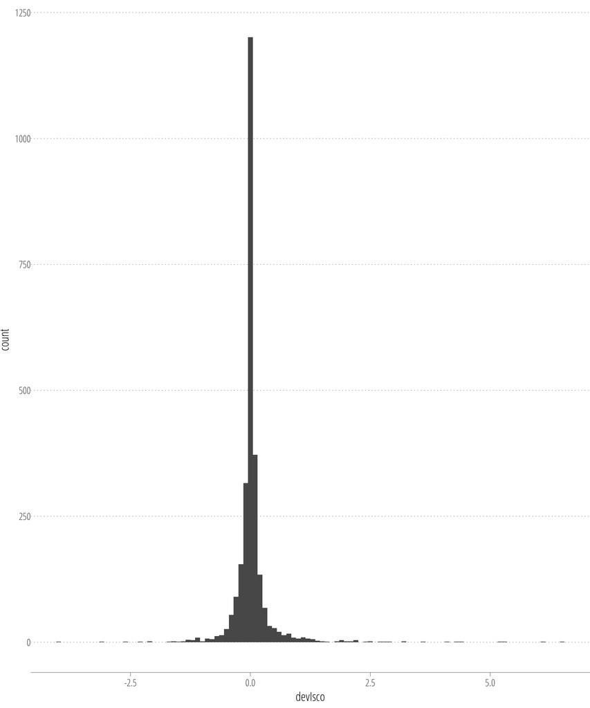

```r
dataa %>% ggplot() + geom_histogram(aes(devIsco), binwidth = 0.1) + swi_theme()
```

```r
## SHow by citizenship deviation
dataa %>% filter(devIsco >= 2) %>%
  knitr::kable(caption = "isco showing a deviation from 2 percentage point against expected/overall share")
```

isco showing a deviation from 2 percentage point against expected/overall share

| isco | description | lieuNaissance | valeur | group | countryTot | dev | shareIsco | iscoTot | shareTot | devIsco |
| --- | --- | --- | --- | --- | --- | --- | --- | --- | --- | --- |
| 3221 | Nursing associate professionals | France | 2801.88 | 3 | 73281.93 | 1.041014 | 3.823425 | 71572.21 | 1.7997234 | 2.023702 |
| 9000 | Elementary occupations, nos | Italie | 4068.88 | 9 | 105881.59 | 5.623356 | 3.842859 | 65870.08 | 1.6563401 | 2.186519 |
| 9110 | Domestic, hotel and office cleaners and helpers, nos | Italie | 4339.21 | 9 | 105881.59 | 5.623356 | 4.098172 | 67549.14 | 1.6985610 | 2.399611 |
| 5120 | Cooks | Portugal | 5691.13 | 5 | 132524.32 | 8.717210 | 4.294404 | 63236.91 | 1.5901276 | 2.704277 |
| 5152 | Domestic housekeepers | Portugal | 3625.06 | 5 | 132524.32 | 8.717210 | 2.735392 | 20304.16 | 0.5105595 | 2.224833 |
| 7112 | Bricklayers and related workers | Portugal | 8933.65 | 7 | 132524.32 | 12.185773 | 6.741140 | 27402.06 | 0.6890402 | 6.052100 |
| 8100 | Stationary plant and machine operators, nos | Portugal | 3807.25 | 8 | 132524.32 | 6.236780 | 2.872869 | 27800.89 | 0.6990690 | 2.173800 |
| 9000 | Elementary occupations, nos | Portugal | 5979.58 | 9 | 132524.32 | 16.249249 | 4.512062 | 65870.08 | 1.6563401 | 2.855722 |
| 9110 | Domestic, hotel and office cleaners and helpers, nos | Portugal | 10843.28 | 9 | 132524.32 | 16.249249 | 8.182106 | 67549.14 | 1.6985610 | 6.483545 |
| 9310 | Mining and construction labourers, nos | Portugal | 3659.00 | 9 | 132524.32 | 16.249249 | 2.761003 | 10102.16 | 0.2540245 | 2.506978 |
| 7112 | Bricklayers and related workers | Espagne | 1045.91 | 7 | 29934.16 | 4.641987 | 3.494035 | 27402.06 | 0.6890402 | 2.804995 |
| 9110 | Domestic, hotel and office cleaners and helpers, nos | Espagne | 1739.51 | 9 | 29934.16 | 7.153233 | 5.811120 | 67549.14 | 1.6985610 | 4.112559 |
| 1120 | Managing directors and chief executives | Autre UE/AELE | 7607.01 | 1 | 152787.75 | 6.315667 | 4.978809 | 111516.67 | 2.8041493 | 2.174660 |
| 5120 | Cooks | Turquie | 1956.09 | 5 | 32889.51 | 7.224773 | 5.947459 | 63236.91 | 1.5901276 | 4.357331 |
| 8100 | Stationary plant and machine operators, nos | Turquie | 914.14 | 8 | 32889.51 | 7.157976 | 2.779427 | 27800.89 | 0.6990690 | 2.080358 |
| 8322 | Car, taxi and van drivers | Turquie | 786.54 | 8 | 32889.51 | 7.157976 | 2.391462 | 12090.98 | 0.3040345 | 2.087427 |
| 9000 | Elementary occupations, nos | Turquie | 2273.05 | 9 | 32889.51 | 13.731608 | 6.911170 | 65870.08 | 1.6563401 | 5.254830 |
| 9110 | Domestic, hotel and office cleaners and helpers, nos | Turquie | 2256.36 | 9 | 32889.51 | 13.731608 | 6.860424 | 67549.14 | 1.6985610 | 5.161863 |
| 1120 | Managing directors and chief executives | Autre OCDE | 2319.30 | 1 | 36218.76 | 9.919382 | 6.403588 | 111516.67 | 2.8041493 | 3.599438 |
| 2330 | Secondary education teachers | Autre OCDE | 1784.93 | 2 | 36218.76 | 17.871248 | 4.928192 | 70246.96 | 1.7663992 | 3.161793 |
| 5120 | Cooks | Autre Non OCDE | 18931.48 | 5 | 394008.11 | 7.629052 | 4.804845 | 63236.91 | 1.5901276 | 3.214718 |
| 9000 | Elementary occupations, nos | Autre Non OCDE | 16388.43 | 9 | 394008.11 | 10.213414 | 4.159414 | 65870.08 | 1.6563401 | 2.503074 |
| 9110 | Domestic, hotel and office cleaners and helpers, nos | Autre Non OCDE | 23807.26 | 9 | 394008.11 | 10.213414 | 6.042327 | 67549.14 | 1.6985610 | 4.343766 |

```r
## Show Swiss vs Foreigners deviations
dataa2 <- data %>% filter(isco >= 1000) %>%
    mutate(group = factor(isco %/% 1000), nat = ifelse(lieuNaissance == "Suisse", "Suisse", "etranger")) %>%
    select(-lieuNaissance)

dataa2 %<>% group_by(isco, nat) %>%
  summarise(valeur = sum(valeur, na.rm = T), description = description[1]) %>%
  ungroup() %>%
  group_by(isco) %>% mutate(tot = sum(valeur, na.rm = T)) %>%
  ungroup() %>%
  mutate(share = (valeur / tot) * 100)

# compute the overall % foreigners
overallShare <- dataa2 %>% group_by(nat) %>% summarise(tot = sum(valeur, na.rm = T)) %>%
  ungroup() %>% mutate(overallShare = (tot / sum(tot))*100) %>% ungroup()

dataa2 <- left_join(dataa2, overallShare %>% select(-tot)) %>%
  mutate(dev = share - overallShare)
cat("\n", "## Top deviations tables", "\n")
```

## Top deviations tables

```r
dataa2 %>% filter(abs(dev) > 30) %>%
    knitr::kable(caption = "isco showing a deviation from 30 percentage point against overall share")
```

isco showing a deviation from 30 percentage point against overall share

| isco | nat | valeur | description | tot | share | overallShare | dev |
| --- | --- | --- | --- | --- | --- | --- | --- |
| 2413 | etranger | 1330.14 | Financial analysts | 2245.99 | 59.222882 | 29.16576 | 30.05712 |
| 2413 | Suisse | 915.85 | Financial analysts | 2245.99 | 40.777118 | 70.83424 | -30.05712 |
| 4212 | etranger | 367.96 | Bookmakers, croupiers and related gaming workers | 516.98 | 71.174900 | 29.16576 | 42.00914 |
| 4212 | Suisse | 149.02 | Bookmakers, croupiers and related gaming workers | 516.98 | 28.825100 | 70.83424 | -42.00914 |
| 5151 | etranger | 1225.82 | Cleaning and housekeeping supervisors in offices, hotels and other establishments | 1976.71 | 62.013143 | 29.16576 | 32.84739 |
| 5151 | Suisse | 750.89 | Cleaning and housekeeping supervisors in offices, hotels and other establishments | 1976.71 | 37.986857 | 70.83424 | -32.84739 |
| 5162 | etranger | 1519.52 | Companions and valets | 1595.57 | 95.233678 | 29.16576 | 66.06792 |
| 5162 | Suisse | 76.05 | Companions and valets | 1595.57 | 4.766322 | 70.83424 | -66.06792 |
| 5169 | etranger | 50.29 | Personal services workers not elsewhere classified | 50.29 | 100.000000 | 29.16576 | 70.83424 |
| 5169 | Suisse | 0.00 | Personal services workers not elsewhere classified | 50.29 | 0.000000 | 70.83424 | -70.83424 |
| 7113 | etranger | 1048.72 | Stonemasons, stone cutters, splitters and carvers | 1683.84 | 62.281452 | 29.16576 | 33.11569 |
| 7113 | Suisse | 635.12 | Stonemasons, stone cutters, splitters and carvers | 1683.84 | 37.718548 | 70.83424 | -33.11569 |
| 7114 | etranger | 2751.81 | Concrete placers, concrete finishers and related workers | 3476.21 | 79.161213 | 29.16576 | 49.99546 |
| 7114 | Suisse | 724.40 | Concrete placers, concrete finishers and related workers | 3476.21 | 20.838787 | 70.83424 | -49.99546 |
| 7119 | etranger | 1418.70 | Building frame and related trades workers not elsewhere classified | 2042.14 | 69.471241 | 29.16576 | 40.30548 |
| 7119 | Suisse | 623.44 | Building frame and related trades workers not elsewhere classified | 2042.14 | 30.528759 | 70.83424 | -40.30548 |
| 7123 | etranger | 7653.52 | Plasterers | 10261.23 | 74.586770 | 29.16576 | 45.42101 |
| 7123 | Suisse | 2607.71 | Plasterers | 10261.23 | 25.413230 | 70.83424 | -45.42101 |
| 7124 | etranger | 3364.31 | Insulation workers | 4609.18 | 72.991508 | 29.16576 | 43.82575 |
| 7124 | Suisse | 1244.87 | Insulation workers | 4609.18 | 27.008492 | 70.83424 | -43.82575 |
| 7212 | etranger | 2303.24 | Welders and flamecutters | 3274.91 | 70.329872 | 29.16576 | 41.16411 |
| 7212 | Suisse | 971.67 | Welders and flamecutters | 3274.91 | 29.670128 | 70.83424 | -41.16411 |
| 7224 | etranger | 1684.87 | Metal polishers, wheel grinders and tool sharpeners | 2837.24 | 59.384120 | 29.16576 | 30.21836 |
| 7224 | Suisse | 1152.37 | Metal polishers, wheel grinders and tool sharpeners | 2837.24 | 40.615880 | 70.83424 | -30.21836 |
| 7541 | etranger | 222.45 | Underwater divers | 222.45 | 100.000000 | 29.16576 | 70.83424 |
| 7541 | Suisse | 0.00 | Underwater divers | 222.45 | 0.000000 | 70.83424 | -70.83424 |
| 7542 | etranger | 192.98 | Shotfirers and blasters | 281.62 | 68.524963 | 29.16576 | 39.35921 |
| 7542 | Suisse | 88.64 | Shotfirers and blasters | 281.62 | 31.475037 | 70.83424 | -39.35921 |
| 8100 | etranger | 17294.60 | Stationary plant and machine operators, nos | 27800.89 | 62.208800 | 29.16576 | 33.04304 |
| 8100 | Suisse | 10506.29 | Stationary plant and machine operators, nos | 27800.89 | 37.791200 | 70.83424 | -33.04304 |
| 8121 | etranger | 1190.60 | Metal processing plant operators | 1927.26 | 61.776823 | 29.16576 | 32.61107 |
| 8121 | Suisse | 736.66 | Metal processing plant operators | 1927.26 | 38.223177 | 70.83424 | -32.61107 |
| 8122 | etranger | 957.84 | Metal finishing, plating and coating machine operators | 1577.49 | 60.719244 | 29.16576 | 31.55349 |
| 8122 | Suisse | 619.65 | Metal finishing, plating and coating machine operators | 1577.49 | 39.280756 | 70.83424 | -31.55349 |
| 8157 | etranger | 3076.48 | Laundry machine operators | 5080.03 | 60.560272 | 29.16576 | 31.39452 |
| 8157 | Suisse | 2003.55 | Laundry machine operators | 5080.03 | 39.439728 | 70.83424 | -31.39452 |
| 8344 | etranger | 1069.57 | Lifting truck operators | 1665.71 | 64.211057 | 29.16576 | 35.04530 |
| 8344 | Suisse | 596.14 | Lifting truck operators | 1665.71 | 35.788943 | 70.83424 | -35.04530 |
| 9100 | etranger | 4684.92 | Cleaners and helpers, nos | 7517.05 | 62.323917 | 29.16576 | 33.15816 |
| 9100 | Suisse | 2832.13 | Cleaners and helpers, nos | 7517.05 | 37.676083 | 70.83424 | -33.15816 |
| 9110 | etranger | 47056.14 | Domestic, hotel and office cleaners and helpers, nos | 67549.14 | 69.662086 | 29.16576 | 40.49633 |
| 9110 | Suisse | 20493.00 | Domestic, hotel and office cleaners and helpers, nos | 67549.14 | 30.337914 | 70.83424 | -40.49633 |
| 9112 | etranger | 4576.68 | Cleaners and helpers in offices, hotels and other establishments | 6664.80 | 68.669427 | 29.16576 | 39.50367 |
| 9112 | Suisse | 2088.12 | Cleaners and helpers in offices, hotels and other establishments | 6664.80 | 31.330573 | 70.83424 | -39.50367 |
| 9121 | etranger | 695.37 | Hand launderers and pressers | 1028.03 | 67.641022 | 29.16576 | 38.47527 |
| 9121 | Suisse | 332.66 | Hand launderers and pressers | 1028.03 | 32.358978 | 70.83424 | -38.47527 |
| 9122 | etranger | 269.10 | Vehicle cleaners | 358.09 | 75.148706 | 29.16576 | 45.98295 |
| 9122 | Suisse | 88.99 | Vehicle cleaners | 358.09 | 24.851294 | 70.83424 | -45.98295 |
| 9211 | etranger | 388.56 | Crop farm labourers | 450.27 | 86.294890 | 29.16576 | 57.12913 |
| 9211 | Suisse | 61.71 | Crop farm labourers | 450.27 | 13.705110 | 70.83424 | -57.12913 |
| 9310 | etranger | 8031.00 | Mining and construction labourers, nos | 10102.16 | 79.497850 | 29.16576 | 50.33209 |
| 9310 | Suisse | 2071.16 | Mining and construction labourers, nos | 10102.16 | 20.502150 | 70.83424 | -50.33209 |
| 9313 | etranger | 526.70 | Building construction labourers | 765.61 | 68.794817 | 29.16576 | 39.62906 |
| 9313 | Suisse | 238.91 | Building construction labourers | 765.61 | 31.205183 | 70.83424 | -39.62906 |
| 9320 | etranger | 11730.31 | Manufacturing labourers, nos | 19471.65 | 60.243020 | 29.16576 | 31.07726 |
| 9320 | Suisse | 7741.34 | Manufacturing labourers, nos | 19471.65 | 39.756980 | 70.83424 | -31.07726 |
| 9412 | etranger | 359.19 | Kitchen helpers | 359.19 | 100.000000 | 29.16576 | 70.83424 |
| 9412 | Suisse | 0.00 | Kitchen helpers | 359.19 | 0.000000 | 70.83424 | -70.83424 |

```r
dataa2 %>% filter(share > 55, nat == "etranger", valeur > 2000) %>% arrange(desc(share)) %>%
     knitr::kable(caption = "jobs where there is a majority of foreigners")
```

jobs where there is a majority of foreigners

| isco | nat | valeur | description | tot | share | overallShare | dev |
| --- | --- | --- | --- | --- | --- | --- | --- |
| 9310 | etranger | 8031.00 | Mining and construction labourers, nos | 10102.16 | 79.49785 | 29.16576 | 50.33209 |
| 7114 | etranger | 2751.81 | Concrete placers, concrete finishers and related workers | 3476.21 | 79.16121 | 29.16576 | 49.99546 |
| 7123 | etranger | 7653.52 | Plasterers | 10261.23 | 74.58677 | 29.16576 | 45.42101 |
| 7124 | etranger | 3364.31 | Insulation workers | 4609.18 | 72.99151 | 29.16576 | 43.82575 |
| 7212 | etranger | 2303.24 | Welders and flamecutters | 3274.91 | 70.32987 | 29.16576 | 41.16411 |
| 9110 | etranger | 47056.14 | Domestic, hotel and office cleaners and helpers, nos | 67549.14 | 69.66209 | 29.16576 | 40.49633 |
| 9112 | etranger | 4576.68 | Cleaners and helpers in offices, hotels and other establishments | 6664.80 | 68.66943 | 29.16576 | 39.50367 |
| 9100 | etranger | 4684.92 | Cleaners and helpers, nos | 7517.05 | 62.32392 | 29.16576 | 33.15816 |
| 8100 | etranger | 17294.60 | Stationary plant and machine operators, nos | 27800.89 | 62.20880 | 29.16576 | 33.04304 |
| 8157 | etranger | 3076.48 | Laundry machine operators | 5080.03 | 60.56027 | 29.16576 | 31.39452 |
| 9320 | etranger | 11730.31 | Manufacturing labourers, nos | 19471.65 | 60.24302 | 29.16576 | 31.07726 |
| 5120 | etranger | 37298.81 | Cooks | 63236.91 | 58.98266 | 29.16576 | 29.81690 |
| 8343 | etranger | 3489.96 | Crane, hoist and related plant operators | 5988.30 | 58.27965 | 29.16576 | 29.11389 |
| 7112 | etranger | 15883.50 | Bricklayers and related workers | 27402.06 | 57.96462 | 29.16576 | 28.79886 |
| 8322 | etranger | 7007.34 | Car, taxi and van drivers | 12090.98 | 57.95510 | 29.16576 | 28.78935 |
| 2643 | etranger | 3112.91 | Translators, interpreters and other linguists | 5496.35 | 56.63595 | 29.16576 | 27.47019 |
| 5152 | etranger | 11487.53 | Domestic housekeepers | 20304.16 | 56.57722 | 29.16576 | 27.41147 |

```r
dataa2 %>% filter(share > 85, nat == "Suisse", valeur > 2000) %>% arrange(desc(share)) %>%
     knitr::kable(caption = "jobs where there is a nearly only Swiss")
```

jobs where there is a nearly only Swiss

| isco | nat | valeur | description | tot | share | overallShare | dev |
| --- | --- | --- | --- | --- | --- | --- | --- |
| 6130 | Suisse | 55576.24 | Mixed crop and animal producers | 57021.16 | 97.46599 | 70.83424 | 26.63175 |
| 5165 | Suisse | 2107.36 | Driving instructors | 2172.38 | 97.00697 | 70.83424 | 26.17273 |
| 3351 | Suisse | 3643.29 | Customs and border inspectors | 3756.62 | 96.98319 | 70.83424 | 26.14895 |
| 6210 | Suisse | 4270.65 | Forestry and related workers | 4568.03 | 93.48997 | 70.83424 | 22.65573 |
| 7320 | Suisse | 4142.21 | Printing trades workers, nos | 4437.27 | 93.35042 | 70.83424 | 22.51617 |
| 8311 | Suisse | 6074.24 | Locomotive engine drivers | 6589.45 | 92.18129 | 70.83424 | 21.34705 |
| 7233 | Suisse | 6586.43 | Agricultural and industrial machinery mechanics and repairers | 7218.57 | 91.24286 | 70.83424 | 20.40862 |
| 3315 | Suisse | 2299.53 | Valuers and loss assessors | 2534.17 | 90.74095 | 70.83424 | 19.90671 |
| 7549 | Suisse | 6548.59 | Craft and related workers not elsewhere classified | 7254.24 | 90.27259 | 70.83424 | 19.43834 |
| 7321 | Suisse | 2438.87 | Pre-press technicians | 2725.67 | 89.47782 | 70.83424 | 18.64357 |
| 3522 | Suisse | 2521.03 | Telecommunications engineering technicians | 2835.74 | 88.90202 | 70.83424 | 18.06777 |
| 5412 | Suisse | 19953.40 | Police officers | 22598.55 | 88.29505 | 70.83424 | 17.46080 |
| 2165 | Suisse | 3059.83 | Cartographers and surveyors | 3468.26 | 88.22378 | 70.83424 | 17.38953 |
| 3353 | Suisse | 2247.05 | Government social benefits officials | 2548.49 | 88.17182 | 70.83424 | 17.33758 |
| 5112 | Suisse | 2505.57 | Transport conductors | 2841.99 | 88.16252 | 70.83424 | 17.32828 |
| 3350 | Suisse | 7016.45 | Regulatory government associate professionals, nos | 7972.49 | 88.00826 | 70.83424 | 17.17402 |
| 2352 | Suisse | 8792.96 | Special needs teachers | 10011.87 | 87.82535 | 70.83424 | 16.99111 |
| 3118 | Suisse | 19472.83 | Draughtspersons | 22280.58 | 87.39822 | 70.83424 | 16.56398 |
| 3213 | Suisse | 9691.05 | Pharmaceutical technicians and assistants | 11134.50 | 87.03624 | 70.83424 | 16.20200 |
| 2341 | Suisse | 50383.67 | Primary school teachers | 58145.98 | 86.65031 | 70.83424 | 15.81606 |
| 3256 | Suisse | 18318.62 | Medical assistants | 21187.37 | 86.46009 | 70.83424 | 15.62585 |
| 2342 | Suisse | 19467.59 | Early childhood educators | 22531.43 | 86.40193 | 70.83424 | 15.56769 |
| 4416 | Suisse | 3596.29 | Personnel clerks | 4184.06 | 85.95216 | 70.83424 | 15.11792 |
| 4311 | Suisse | 3592.03 | Accounting and bookkeeping clerks | 4180.34 | 85.92674 | 70.83424 | 15.09250 |
| 3113 | Suisse | 3649.30 | Electrical engineering technicians | 4251.78 | 85.82993 | 70.83424 | 14.99569 |
| 3324 | Suisse | 40756.31 | Trade brokers | 47621.64 | 85.58359 | 70.83424 | 14.74935 |
| 3344 | Suisse | 8011.29 | Medical secretaries | 9365.66 | 85.53898 | 70.83424 | 14.70474 |
| 1323 | Suisse | 3505.72 | Construction managers | 4108.39 | 85.33075 | 70.83424 | 14.49651 |
| 2320 | Suisse | 10409.26 | Vocational education teachers | 12234.10 | 85.08399 | 70.83424 | 14.24974 |

```r
# dataa %>% filter(abs(dev) >= 4) %>%
#   group_by(group, lieuNaissance) %>%
#   filter(devIsco > 1) %>%
#   select(description, valeur, devIsco) %>%
#   ungroup() %>% View()

## Compute deviation for detailed isco codes but for Swiss vs non-Swiss
datab <- data %>%
  filter(isco >= 1000) %>%
  mutate(origin = ifelse(lieuNaissance == "Suisse", "Suisse", "Etranger")) %>%
  group_by(isco, description, origin) %>%
  summarise(valeur = sum(valeur, na.rm = T)) %>%
  ungroup() %>%
  group_by(isco, description) %>%
  mutate(totIsco = sum(valeur, na.rm = T)) %>%
  ungroup() %>%
  mutate(share = (valeur / totIsco) * 100)

datac <- data %>%
  filter(isco >= 1000) %>%
  mutate(origin = ifelse(lieuNaissance == "Suisse", "Suisse", "Etranger")) %>%
  mutate(group = isco %/% 1000) %>%
  group_by(group, origin) %>%
  summarise(totGroupOri = sum(valeur, na.rm = T)) %>%
  ungroup() %>%
  group_by(group) %>%
  mutate(totGroup = sum(totGroupOri), shareGroup = (totGroupOri / totGroup)) %>%
  ungroup() %>%
  mutate(shareGroupTot = (totGroup / (sum(totGroup) /2 ) )) %>%
  group_by(origin) %>%
  mutate(totOri = sum(totGroupOri)) %>%
  ungroup() %>%
  mutate(sharebyOri = (totGroupOri / totOri), dev = sharebyOri - shareGroupTot)


if(exportRawData) {
  datac %>% select(group, origin, totGroupOri) %>%
    mutate(origin = ifelse(origin == "Suisse", "swiss", "foreigner")) %>%
    rename(value = totGroupOri) %>%
    write_csv(path = "data/isco1_byNationality.csv")
}

if(displayExplore) {
  datac %>% ggplot(aes(group, shareGroup)) + geom_bar(aes(fill = origin), position = "dodge", stat="identity")
  datac %>% ggplot(aes(group, shareGroup)) + geom_bar(aes(fill = origin), position = "stack", stat="identity") + swi_theme()
}
```

# Production graphics

### Profession groups by Swiss/Foreigners and number of jobs

Inspirations: [WSJ](http://www.wsj.com/graphics/us-mexico-trade/)

```r
i.colors <- c('#4c6570', '#b15953')

# https://learnr.wordpress.com/2009/03/29/ggplot2_marimekko_mosaic_chart/
library(ggiraph)

# compute rect positions
dd <- datac %>% select(group, origin, totGroupOri, shareGroupTot, shareGroup) %>%
  group_by(origin) %>% arrange(desc(group)) %>%
  mutate(ymax = cumsum(shareGroupTot), ymin = ymax - shareGroupTot) %>%
  ungroup() %>%
  group_by(group) %>% arrange(desc(origin)) %>%
  mutate(xmax = cumsum(shareGroup), xmin = xmax - shareGroup) %>%
  ungroup()

# compute the average % non-Suisse for all jobs
tot <- dd %>% group_by(origin) %>%
  summarise(sum(totGroupOri)) %>% ungroup()
meanCH <- (tot[tot$origin == "Suisse", 2] / tot[,2] %>%
             sum()) %>% unlist(use.names = F)

labels <- dd %>% filter(origin == "Suisse") %>%
  mutate(y = ymax - 0.01, yRange = (ymax - ymin)* 100) %>%
  select(group, origin, xmin, y, yRange) %>%
  ungroup()

lang <- 'FR'

plotProportionalStackedBar <- function(ddd, txt, lang) {
  lang_ori <- lang
  if(lang == "AR") {
    lang <- 'EN'
  }
  # add translation
  labels$label <- txt[as.character(labels$group), lang]
  ddd$label <- txt[as.character(ddd$group), lang]
  ddd$orilab <- txt[ifelse(ddd$origin == "Suisse", "ori.CH", "ori.nonCH"), lang]
  size_annotate_foreigner <- case_when(
    lang == "RU" ~ 10,
    lang %in% c("ZH", "JA") ~ 11,
    TRUE ~ 14
  )

  ddd %<>%
    mutate(
      id = paste0(origin, group),
      tp = paste0(#'<div class = "tp">',
      "<em>", label, "</em><br><hr>",
      orilab, " <b>", round(shareGroup * 100, 1), "%</b><br>", "(",
      prettyNum(round(totGroupOri), big.mark = " ", mode = "character"), " ",
      txt["job", lang], ")"#,
      # '</div>'
  ))
  ddd %<>% mutate(tp = gsub("'", "`", tp))

  gp <- ggplot(ddd) +
    annotate(geom = "text", x = 0.99, y = 0.5, label = paste(strsplit(txt['ori.nonCH', lang], "")[[1]], collapse = " "),
             colour = "#193442", alpha = 0.9, angle = -90, vjust = 1, hjust = 0.5, size = size_annotate_foreigner, fontface = "bold") +
    geom_rect_interactive(
      aes(ymin = ymin, ymax = ymax, xmin = xmin, xmax = xmax, fill = origin, data_id = id, tooltip = tp),
      colour = "white", size = 0.25, alpha = 0.95
    ) +
  scale_x_continuous(position = "top", expand = c(0.01, 0.01),
                     labels = scales::percent, breaks = scales::pretty_breaks(n = 4)) +
  scale_y_continuous(expand = c(0,0), limits = c(0, 1.02)) +
  scale_fill_manual(values = i.colors,
                    guide_legend(title = txt['leg.title', lang]),
                    breaks = c(txt["ori.CH", lang], txt[ "ori.nonCH", lang])) +
  swi_theme(y_gridlines = F, base_size = 13, base_family = "Open Sans Condensed") +
  theme(
    axis.line.x = element_blank(),
    axis.ticks.y = element_blank(),
    axis.text.y = element_blank(),
    axis.title = element_blank(),
    #axis.ticks.length = unit(0.15,"cm"),
    # disable legend! #
    legend.position = "none",
    plot.margin = unit(c(0.15, 0, 0.3, -0.2), "cm")
    # plot.margin = unit(c(0, 0, 0.3, -0.2), "cm"),
    # legend.position = "top",
    # legend.key.height = unit(10, "points"),
    # legend.title = element_text(size = 11),
    # legend.text = element_text(size = 10)
  )

  gp2 <- gp +
    geom_segment(data = tibble(x = meanCH, xend = meanCH, y = 0, yend = 1),
                 aes(x = x, y = y, xend = xend, yend = yend),
                 linetype = "dotted", colour = "#333333", size = 0.85, alpha = 0.95) +
    annotate(geom = "text", x = meanCH,  y = 1.02,
             label = txt["average" , lang], vjust = 1, hjust = 0.5,
             family = "Open Sans Condensed", colour =  "#193442", size = 3.2) +
    geom_text(data = labels,
              aes(x = xmin + 0.008, y = y, label = label, size = yRange),
              hjust = 0, vjust = 1, colour = "white", family = "Open Sans Condensed") +
    scale_size_continuous(range = c(2.2, 6), guide = F)

  gp3 <- gp2 +
    geom_text(data = ddd %>% filter(origin == "Suisse"),
              aes(x = xmax, y = ymax - 0.005, label = paste0(round(shareGroup * 100), "%")),
              hjust = 1.05, vjust = 1, size = 3, alpha = 0.65,
              colour = "white", family = "Open Sans Condensed"
    ) +
    geom_text(data = ddd %>% filter(origin == "Etranger"),
              aes(x = xmin, y = ymax - 0.005, label = paste0(round(shareGroup * 100), "%")),
              hjust = -0.25, vjust = 1, size = 3, alpha = 0.65,
              colour = "white", family = "Open Sans Condensed"
    )

  gpi <- ggiraph(
    code = {print(gp3)},
    hover_css =  "opacity:0.75;cursor:pointer;",
    tooltip_opacity = 0.8,
    tooltip_extra_css = "padding:4px;margin:2px;border-radius:3.5px;background-color:#d9d9d9;font-size:1em;",
    tooltip_offx = -17,
    pointsize = 11,
    width = 1,
    width_svg = 6,
    height_svg = 7.7,
    fonts = list(sans = "Open Sans Condensed", serif = "Open Sans Condensed")
  )

  source <- paste0(
    txt['source', lang_ori], ": ", htmlLink('http://nccr-onthemove.ch', txt['source.name', lang_ori]), " | swissinfo.ch | @duc_qn"
  )
  if(lang_ori == 'AR') {
    footer <- paste0(txt[as.character(rev(labels$group)), lang], "&nbsp;:&nbsp;", txt[as.character(rev(labels$group)), lang_ori], collapse = ", ")
  } else {
    footer <- ""
  }

  save_html(
    tags$html(
      dir = ifelse(lang_ori == "AR", "rtl", "ltr"),
      tags$head(includeHTML("styles.html")),
      tags$body(
        h2(HTML(txt['main.title', lang_ori] )),
        div(class = "descr", HTML(paste0('<img src="https://interactive.swissinfo.ch/assets/Interactive_icon.svg.png" width="13" align="top">&nbsp; ', txt['descr', lang_ori] ))),
        h3(HTML(txt['h3', lang_ori])),
        div(dir="ltr", gpi),
        div(class="footer", HTML(footer)),
        div(id = "cite", HTML(source)),
        HTML(iframeresizer)
     )
    ),
    file =  paste0("occupationsByISCOandSwiss_", lang_ori, ".html"), libdir = "js")
}

#plotProportionalStackedBar(dd, txt)
for (lang in colnames(txt)) {
  cat("\n", lang)
  plotProportionalStackedBar(dd, txt, lang)
}
```

```
##
##  EN
```

```
##
##  FR
```

```
##
##  DE
```

```
##
##  IT
```

```
##
##  PT
```

```
##
##  AR
```

```
##
##  RU
```

```
##
##  ES
```

```
##
##  JA
```

```
##
##  ZH
```

### Profession group by country of birth and number of jobs

```r
chart.height <- 270 #223
bg.colour <-  "#f2f2f2"
y.max <- adat %>% select(dev) %>% range()
# scale dev
#adat %<>% mutate(alpha = rescale(abs(dev), to = c(0.8, 1)))
adat %<>% mutate(alpha = ifelse(dev >= 0, 1, 0.5))

adat %<>%
  group_by(group) %>%
  mutate(shareLieuNaissance = (countryTot / sum(countryTot) * 100)) %>%
  ungroup()

plotOriginColumn <- function(adat, origin, txt) {

  originLabel <- txt[origin, lang]

  ddd <- adat %>%
    filter(lieuNaissance == origin) %>%
    mutate(
      groupLabel = txt[as.character(group), lang],
      tp = paste0(
        "<em>", groupLabel, "</em><br><b>",
        ifelse(dev > 0, "+", ""), round(dev, 1), "</b> ", txt["tp.pp", lang], "<br><small>",
        "(<b>", round(share, 1), "% </b>", txt["tp.vs", lang], " ",
        round(shareTot, 1), "% ", txt["tp.tot", lang], ") ",
        prettyNum(round(valeur), big.mark = " ", mode = "character"), " ", txt["job", lang],
        "</small>"
      )
    )

  h.colors <- sapply(1:length(colors), function(i) hex_to_rgba(colors[i], ddd$alpha[i]))
  #h.colors <- ifelse(ddd$dev > 0, colors, "#8c8c8c")

  cchart <- hchart(
    ddd, "column", hcaes(x = groupLabel, y = dev, tp, tp)
  ) %>%
    hc_add_theme(hc_theme_swi) %>%
    hc_legend(enabled = F) %>%
    hc_chart(
      backgroundColor = bg.colour, height = chart.height,
      spacing = list(3,4,1,-15), borderRadius = 3,
      borderColor = "white", borderWidth = 1
    ) %>%
    hc_xAxis(
      offset = -25,
      useHTML = T, tickLength = 0, lineWidth = 0,
      labels = list(autoRotation = list(0), useHTML =  ifelse(lang == "AR", T, F),
                    padding = 10, y = 3,
                    style = list(fontSize = "0.65em", color = "#404040", textOverflow = 'none')),
      gridLineWidth = 0,  title = "", reversed = ifelse(lang == "AR", T, F)
    ) %>%
    hc_yAxis(
      useHTML = T, labels = list(format = paste('{value}', txt['y.pp', lang]), style = list(fontSize = "0.85em")),
      gridLineWidth = 1, tickPositions = list(-10, 10), offset = -16,
      minPadding = 0, maxPadding = 0, min = y.max[1], max = y.max[2],
      startOnTick = F, endOnTick = F, #start-endOnTick are essential to have the axis extend beyong ticks!!!
      title = "", opposite = ifelse(lang == "AR", T, F),
      plotLines = list(list(color = "#666666", width = 1.4, value = 0, zIndex = 5))
    ) %>%
    hc_plotOptions(column = list(colorByPoint = T, colors = h.colors,
                                 borderRadius = 1, borderColor = bg.colour,
                                 borderWidth = 0,
                                 pointPadding = 0.01, groupPadding = 0.01,
                                 states = list(hover = list( brightness = 0.2,
                                 color = "#333333", borderColor = "#333333")))
    )

    cchart %>% hc_tooltip(
      hideDelay = 10, formatter = JS("function() { return this.point.tp; }"),
      useHTML = T, borderWidth = 1,
      backgroundColor = 'rgba(255,255,255,1)', style = list(padding = 4, fontSize = "0.9em")
    ) %>%
      hc_title(
        floating = T, align = "center", useHTML = ifelse(lang == "AR", T, F),
        text = originLabel, x = 20, y = 20,
        style = list("fontSize" = "16px", "color" = '#2d3639')
    ) %>%
      hc_subtitle(
        floating = T, align = "right", useHTML =  ifelse(lang == "AR", T, F),
        text = paste0(round(unique(ddd$shareLieuNaissance), 1), "% ", txt["st.job", lang]),
        x = -3, y = 10,
        style = list("fontSize" = "12px", "color" = "#454545")
      )
}

## Loop by language
lieuNaissance.ordered <- c(
  "Allemagne", "France", "Italie", "Portugal", "Espagne", "Autre UE/AELE",
  "Turquie", "Autre OCDE", "Autre Non OCDE", "Suisse"
)
stopifnot(lieuNaissance.ordered %in% adat$lieuNaissance, adat$lieuNaissance %in% lieuNaissance.ordered)

for (lang in colnames(txt)) {
  cat("\n", lang)
  plots <- lapply(lieuNaissance.ordered, function(nat) plotOriginColumn(adat, nat, txt))
  source <- paste0(
    txt['source', lang], ": ", htmlLink('http://nccr-onthemove.ch', txt['source.name', lang]), " | swissinfo.ch"
  )

  save_html(
    tags$html(
      dir = ifelse(lang == "AR", "rtl", "ltr"),
      tags$head(includeHTML(style_swi_highcharter())),
      tags$body(
        h2(HTML(txt['main.title2', lang])),
        div(class = "descr", HTML(paste0('<img src="https://interactive.swissinfo.ch/assets/Interactive_icon.svg.png" width="12" align="top">&nbsp; ', txt['descr2', lang]))),
        h3(HTML(txt['h3b', lang])),
        div(class = "graphic", hw_grid(plots, ncol = 2, rowheight = chart.height)),
        div(id = "cite", HTML(source)),
        HTML(iframeresizer)
      )
    ),
    file =  paste0("jobByCountryBirth_", lang, ".html"), libdir = "js")
}
```

```
##
##  EN
##  FR
##  DE
##  IT
##  PT
##  AR
##  RU
##  ES
##  JA
##  ZH
```

```r
if(cleanOutput) {
  files <- c("jobByCountryBirth_.*", "occupationsByISCOandSwiss_.*", "js")

  if(!dir.exists("output/bak")) {
    dir.create("output/bak")
  } else {
    list.files("output/bak/", full.names = T, recursive = T) %>% file.remove()
  }
  ori.files <- list.files("output", full.names = T)[list.files("output") != "bak"]
  file.copy(ori.files, to = "output/bak/", recursive = T)
  unlink(ori.files, recursive = T)

  files_tomove <- lapply(files, function(x) list.files(pattern = x)) %>% unlist()
  file.copy(files_tomove, "output", recursive = T)
  unlink(files_tomove, recursive = T)
}
```